# HoloFoodR R package — case study

Published

October 17, 2024

## Introduction

[HoloFood database](https://www.holofooddata.org) is a large collection of holo-omic and multi-omic data from two animal systems, chicken and salmon. It was created by the HoloFood consortium. One of its objectives is to study the interactions between animal systems, their microbiomes, and feed additives to optimize the diet strategies of these farm animals. For make it easily accessible, the creators provide an Application Programming Interface (API) that permits interaction with programming languages, such as R or Python.

We improve the accessibility by creating the HoloFoodR package that simplifies API interaction and assists translating raw database data into R/Bioconductor data containers, connecting to a vast ecosystem of bioinformatics R packages.

We do not aim to demonstrate HoloFoodR in isolation from the rest of the ecosystem, but to showcase the possibility of data integration from other databases, such as MGnify, which holds metagenomic data. Furthermore, we provide a workflow from data exploration to advanced machine learning and multi-omics, offering a practical example for readers.

Our main study questions are:

```
- Do treatment associate with salmons' gut flora?
- Do larger salmons have different gut microbiota compared to smaller ones?
- Do gut microbiota have association with muscle tissue fatty acids?
```

```r
# List of packages that we need
packages <- c(
    "ComplexHeatmap", "dplyr", "DT", "ggplot2", "ggpubr", "ggsignif", "HoloFoodR", "knitr",
    "latex2exp", "MGnifyR", "mia", "miaViz", "MOFA2", "patchwork", "reticulate",
    "scater", "shadowtext", "stringr"
)

# Get packages that are already installed installed
packages_already_installed <- packages[packages %in% installed.packages()]

# Get packages that need to be installed
packages_need_to_install <- setdiff(packages, packages_already_installed)

# Loads BiocManager into the session. Install it if it not already installed.
if (!require("BiocManager")) {
    install.packages("BiocManager")
    library("BiocManager")
}
# If there are packages that need to be installed, installs them with
# BiocManager Updates old packages
if (length(packages_need_to_install) > 0) {
    install(packages_need_to_install, ask = FALSE)
}

# Load all packages into session. Stop if there are packages that were not
# successfully loaded
pkgs_not_loaded <- !sapply(packages, require, character.only = TRUE)
```

[output not shown]

```r
pkgs_not_loaded <- names(pkgs_not_loaded)[pkgs_not_loaded]
if (length(pkgs_not_loaded) > 0) {
    stop("Error in loading the following packages into the session: '", paste0(pkgs_not_loaded, collapse = "', '"), "'")
}
```

## Import data

We start the workflow from data retrieval. We will use [salmon data](https://www.holofooddata.org/samples/?animal__system=salmon) and its associated fatty acid and metagenomic amplicon as an example.

### Retrieve HoloFood data

First of all, we have to query the HoloFood database to retrieve the salmon accession numbers.

```r
# Get salmon samples
salmons <- HoloFoodR::doQuery("animals", system = "salmon", use.cache = TRUE)

# Get only the data that has both metagenomic amplicion and fatty acid
# data
salmons <- salmons |>
    filter(fatty_acids == TRUE & metagenomic_amplicon == TRUE)

colnames(salmons)
```

Next, we can retrieve the data associated with each salmon.

```r
# Get salmon data
salmon_data <- HoloFoodR::getData(
    accession.type = "animals",
    accession = salmons[["accession"]],
    use.cache = TRUE
)

# Get salmon samples
salmon_samples <- salmon_data[["samples"]]

# Get sample IDs
salmon_sample_ids <- unique(salmon_samples[["accession"]])

head(salmon_sample_ids)
```

The data returned above is a list of all sample accession numbers that are associated with all salmons. For example, metagenomic amplicon samples, such as SAMEA112750580 or genomic sample, such as SAMEA9068691.

We can use these accession numbers to fetch the data associated with each sample type and store them as `experiments` in a MultiAssayExperiment (MAE) object.

```r
# Get salmon <- experiments as MAE object
mae <- HoloFoodR::getResult(
    salmon_sample_ids,
    use.cache = TRUE
)
```

### Fetch metagenomic data from MGnify

HoloFood database does not include the data for metagenomic data. This data can be retrieved from the [MGnify portal](https://www.ebi.ac.uk/metagenomics). For this purpose, we will use MGnifyR package, which in a similar fashion to HoloFoodR, allows simple interaction with MGnify API.

```r
# Create MGnify object
mg <- MgnifyClient(
    useCache = TRUE,
    cacheDir = ".MGnifyR_cache"
)

# Select only metagenomic_amplicon sample type
metagenomic_salmon_samples <- salmon_samples |>
    filter(sample_type = "metagenomic_amplicon")

# Search for sample IDs in MGnify database
salmon_analysis_ids <- searchAnalysis(
    mg,
    type = "samples",
    metagenomic_salmon_samples[["accession"]]
)
```

`salmon_analysis_ids` character vector holds associations of HoloFood metagenomic amplicon accession numbers (SAMEAxxxxxx) to their counterparts in MGnify database (MGYAxxxxxx).

```r
# Get metagenomic taxonomic data for salmon from MGnify
tse <- MGnifyR::getResult(
    mg,
    accession = salmon_analysis_ids,
    get.func = FALSE
)
```

Data fetched from MGnify has MGnify-specific identifiers. We have to first rename samples with HoloFood specific ID and then add the data to MultiAssayExperiment combining all the data.

```r
# Add MGnify results to HoloFood data
mae <- addMGnify(tse, mae)
```

Now we have retrieved all the data that we are interested in this workflow.

## Data preprocess

Data cleaning is one of the most time-consuming and most important steps in data analysis. For instance, we need to handle missing data, transform data assays, and agglomerate the data.

In the next steps, we will:

1. Remove unnecessary data
2. Ensure that the data is in correct format for analysis
3. Agglomerate data
4. Transform data

### Wrangle the data

Below we see upset plot that summarizes the available experiments and how samples overlap between them.

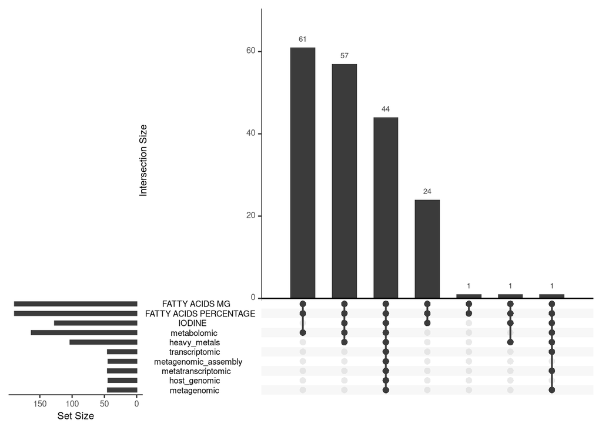

```r
upsetSamples(mae)
```

For demonstration purposes, we will focus on investigating fatty acids and metagenomic data (`fatty_acids_mg` and `metagenomic_amplicon`) within the trial A performed by the HoloFood consortium. This trial the health effects of fermented seaweed added to the diet of salmons.

```r
# Harmonize experiment names
names(mae) <- names(mae) |>
    tolower() |>
    gsub(pattern = " ", replacement = "_")

# Fetch only experiments that we need
mae <- mae[, , c("fatty_acids_mg", "metagenomic")]
```

```
#> harmonizing input:
#>   removing 934 sampleMap rows not in names(experiments)
```

```r
names(mae) <- c("fatty_acids", "metagenomic")
# Filter MAE object to include only Trial A
mae <- mae[, colData(mae)[["Trial code"]] == "SA", ]
```

Some values of fatty acids are under detection thresholds. We assume them to be zeroes.

```r
# From metabolomic data, remove organ-fatty acids row because it only contains a
# string value "muscle" which denotes where the sample was drawn.
tse <- mae[[1]]
tse <- tse[!(rowData(tse)[["marker.name"]] %in% c("Organ-fatty acids")), ]
mae[[1]] <- tse

# Transform matrix to numeric. Some values are "< 0.01"
# If a number is < 0.01, assume it to be 0
assay <- assay(mae[[1]], "counts")
assay[assay == "<0.01"] <- 0
assay <- apply(assay, c(1, 2), function(x) as.numeric(gsub(",", ".", x)))

# Reassign assay back to MAE
assay(mae[[1]], "counts") <- assay
```

Moreover, we wrangle the sample metadata so that it includes all necessary information.

```r
# Add treatment groups
colData(mae)[["treatment_group"]] <- ifelse(
  colData(mae)[["Treatment concentration"]]>0, "treatment", "control")

# Add salmon host mass to MAE colData
colData(mae[[2]])[["host.gutted.mass"]] <- as.numeric(
    colData(mae[[2]])[["host.gutted.mass"]])
merged_data <- merge(
    x = colData(mae), y = colData(mae[[2]])[, c("animal", "host.gutted.mass")],
    all.x = TRUE, by = "animal"
)
rownames(merged_data) <- merged_data[["animal"]]
# Order and add back
colData(mae) <- merged_data[match(
    colData(mae)[["animal"]], merged_data[["animal"]]), ]

# Add animal metadata to separate experiments
mae[[1]] <- getWithColData(mae, 1)
mae[[2]] <- getWithColData(mae, 2)
```

Furthermore, as we want to analyze the effect of treatment, we must analyze salmons at day 60 because these salmons were sampled after experimental period. In contrast, day-0 salmons that were sampled immediately in the beginning of the trial.

We select those samples that are drawn in day 60.

```r
# Subset by taking only samples from day 60
samples <- colnames(mae[[2]])[mae[[2]]$trial.timepoint == 60]
mae[[2]] <- mae[[2]][, samples]
```

```
#> harmonizing input:
#>   removing 15 sampleMap rows with 'colname' not in colnames of experiments
```

```r
# Make sure that we have same set of samples from each experiment
mae <- intersectColumns(mae)
```

Now the data includes samples that are taken in day 60. Each animal have both microbiota data and fatty acid data.

### Filtering and agglomeration

Next, we can agglomerate features by prevalence to reduce the number of low-abundant taxa and contaminants.

First, we visualize prevalence distribution with a histogram to decide the prevalence threshold to use. We use 0.1% detection level to filter out extremely low-abundant taxa present in each sample.

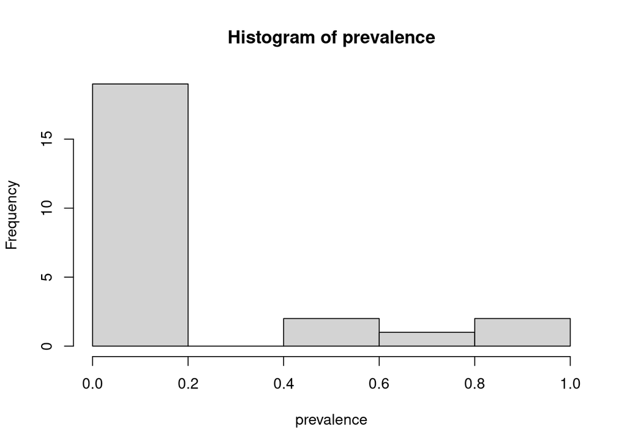

```r
# Add relative transforrmed data
mae[[2]] <- transformAssay(mae[[2]], method = "relabundance")

prevalence <- getPrevalence(
    mae[[2]],
    rank = "Genus",
    assay.type = "relabundance",
    na.rm = TRUE,
    sort = TRUE,
    detection = 0.1 / 100
)

# Exclude microbes with 0 prevalence
prevalence <- prevalence[prevalence != 0]

hist(prevalence)
```

We can also look at the raw prevalence numbers

```r
# Sort prevalence in decreasing order
sort(prevalence, decreasing = TRUE) |> head(10)
```

```
#>     Mycoplasma Photobacterium     Aliivibrio  Cetobacterium         Vibrio
#>      1.0000000      0.9666667      0.6666667      0.6000000      0.5000000
#> Ammopiptanthus  Mycobacterium       Medicago    Paucibacter   Enterococcus
#>      0.2000000      0.1666667      0.1333333      0.1000000      0.1000000
```

*Mycoplasma* is present in all samples, which is not surprising as this genus was found to be one of the most common in salmon intestine (see Zarkasi et al. (2014)).

```r
# Agglomerate by prevalence by genus
altExp(mae[[2]], "prev_genus") <- agglomerateByPrevalence(
    mae[[2]],
    assay.type = "relabundance",
    rank = "Genus",
    prevalence = 0.2 / 100,
    detection = 0.1 / 100
)
```

```r
tse <- agglomerateByRank(mae[[2]], rank = "Genus")
core <- getTop(tse, top = 19)
# Get vector that tells whether taxa belongs to core taxa or not
core_names <- rownames(tse)
core_names[ !core_names %in% core ] <- "other"
# Agglomerate based on core taxa
rowData(tse)[["core"]] <- core_names
altExp(mae[[2]], "core_genus") <- agglomerateByVariable(tse, by = "rows", group = "core")
```

Due to the limited number of samples, we also filter the fatty acid data to include only those fatty acids that show variation within the dataset. The rationale is that if a fatty acid does not vary, it cannot exhibit differences between groups.

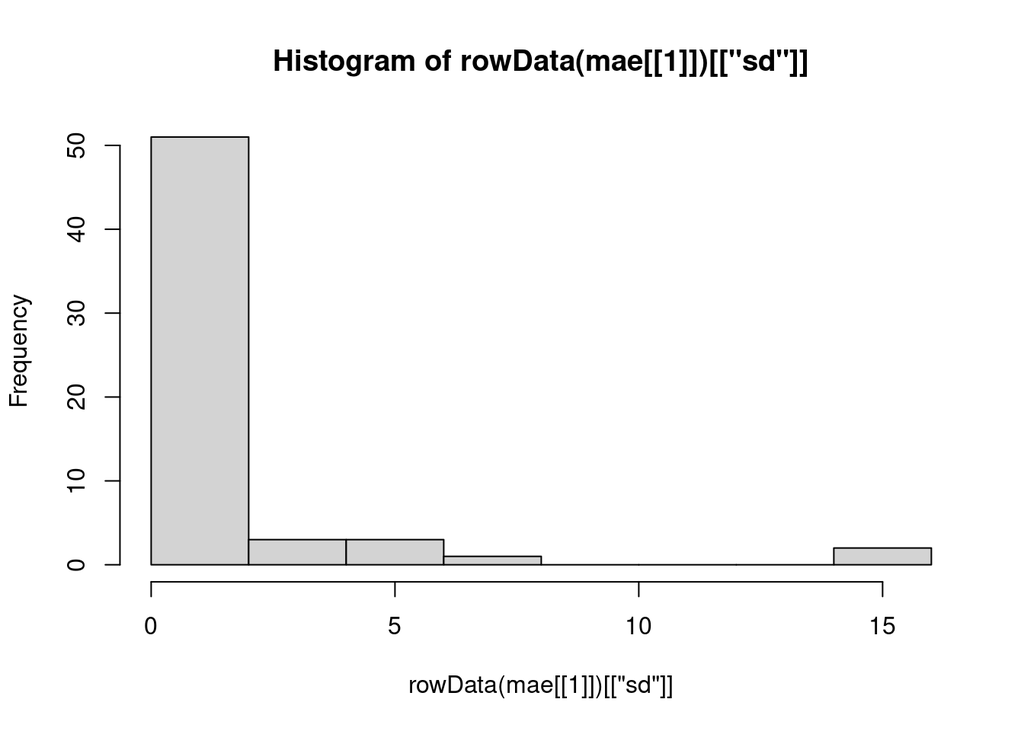

```r
rowData(mae[[1]])[["sd"]] <- rowSds(assay(mae[[1]], "counts"), na.rm = TRUE)
hist(rowData(mae[[1]])[["sd"]])
```

```r
mae[[1]] <- mae[[1]][ rowData(mae[[1]])[["sd"]] > 0.5, ]
```

For more detailed analysis, we pick certain fatty acids that have well-established biological relevance. These include 22:6n-3, 20:5n-3, 18:3n-3, 20:4n-6, 18:2n-6, 18:1n-9, 16:0, and 18:0.

```r
relevant_fatty_acids <- c(
  "Docosahexaenoic acid 22:6n-3 (DHA)",
  "Eicosapentaenoic acid 20:5n-3 (EPA)",
  "Alpha-Linolenic acid 18:3n-3",
  "Arachidonic acid 20:4n-6 (ARA)",
  "Linoleic acid 18:2n-6",
  "Oleic acid 18:1n-9",
  "Palmitic acid 16:0",
  "Stearic acid 18:0"
)
altExp(mae[[1]], "relevant") <- mae[[1]][
    rownames(mae[[1]]) %in% relevant_fatty_acids, ]
```

### Transformation

We transform metagenomic counts first with centered log-ratio method to tackle the compositional data (see Quinn et al. (2019)).

```r
# Transform microbiome with centered log-ratio method
mae[[2]] <- transformAssay(
    mae[[2]],
    assay.type = "counts",
    method = "relabundance",
    MARGIN = "cols"
)
mae[[2]] <- transformAssay(
    mae[[2]],
    assay.type = "counts",
    method = "clr",
    pseudocount = TRUE,
    MARGIN = "cols"
)
```

```
#> A pseudocount of 0.5 was applied.
#> A pseudocount of 0.5 was applied.
#> A pseudocount of 0.5 was applied.
```

```r
mae[[1]] <- transformAssay(
    mae[[1]],
    assay.type = "counts",
    method = "log10",
    MARGIN = "cols"
)
mae[[1]] <- transformAssay(
    mae[[1]],
    assay.type = "log10",
    method = "standardize",
    MARGIN = "rows"
)
```

## Fatty acids, mass and treatment

### Does treatment affect fatty acids?

We aim to investigate whether the treatment is associated with changes in fatty acid concentrations. To begin, we assess the correlation between treatment levels and the concentrations of specific fatty acids

```r
# Get fatty acids that we are going to test
tse <- altExp(mae[[1]], "relevant")

# For each fatty acid, test if the groups are different
res <- lapply(rownames(tse), function(feat){
    res <- pairwise.wilcox.test(
      assay(tse, "counts")[feat, ], tse[["treatment_group"]],
      p.adjust.method = "none")
    return(res)
})
# Combine results and adjust p -values
res <- do.call(rbind, res) |> as.data.frame()
res[["p.value"]] <- p.adjust(res[["p.value"]], method = "fdr")
res |> datatable()
```

|  | method | data.name | p.value | p.adjust.method |
| --- | --- | --- | --- | --- |
| 1 | ['Wilcoxon rank sum test with continuity correction'] | ['assay(tse, "counts")[feat, ] and tse[["treatment_group"]]'] | 0.9173929463944336 | ['none'] |
| 2 | ['Wilcoxon rank sum test with continuity correction'] | ['assay(tse, "counts")[feat, ] and tse[["treatment_group"]]'] | 0.5065184394702462 | ['none'] |
| 3 | ['Wilcoxon rank sum test with continuity correction'] | ['assay(tse, "counts")[feat, ] and tse[["treatment_group"]]'] | 0.8668974111262169 | ['none'] |
| 4 | ['Wilcoxon rank sum exact test'] | ['assay(tse, "counts")[feat, ] and tse[["treatment_group"]]'] | 0.8668974111262169 | ['none'] |
| 5 | ['Wilcoxon rank sum test with continuity correction'] | ['assay(tse, "counts")[feat, ] and tse[["treatment_group"]]'] | 0.8668974111262169 | ['none'] |

As observed, the treatment appears to have no significant effect on fatty acid concentrations.

### Is there association between salmon size and fatty acids?

Additionally, it is worth exploring whether the size of the salmon is associated with variations in fatty acid levels.

```r
# Calculate correlation
res <- getCrossAssociation(
    mae, experiment1 = 1, experiment2 = 1, altexp1 = "relevant",
    assay.type1 = "counts", col.var2 = "host.gutted.mass",
    test.signif = TRUE, method = "spearman"
)
```

```
#> Calculating correlations...
#> altexp1: relevant, altexp2: -, assay.type1: counts, col.var1: -, assay.type2: -, col.var2: host.gutted.mass
#> by: 1, function: stats::cor.test, method: spearman, test.signif: TRUE, p.adj.method: fdr, paired: FALSE, show.warnings: TRUE
#> Warning in cor.test.default(feature1, feature2, method = method, use =
#> "pairwise.complete.obs"): Cannot compute exact p-value with ties
#> Warning in cor.test.default(feature1, feature2, method = method, use =
#> "pairwise.complete.obs"): Cannot compute exact p-value with ties
#> Warning in cor.test.default(feature1, feature2, method = method, use =
#> "pairwise.complete.obs"): Cannot compute exact p-value with ties
#> Warning in cor.test.default(feature1, feature2, method = method, use =
#> "pairwise.complete.obs"): Cannot compute exact p-value with ties
```

```r
res
```

```
#>                                  Var1             Var2       cor       pval
#> 1  Docosahexaenoic acid 22:6n-3 (DHA) host.gutted.mass 0.4221184 0.02014763
#> 2 Eicosapentaenoic acid 20:5n-3 (EPA) host.gutted.mass 0.3562132 0.05335097
#> 3               Linoleic acid 18:2n-6 host.gutted.mass 0.2685505 0.15130868
#> 4                  Oleic acid 18:1n-9 host.gutted.mass 0.2640712 0.15812558
#> 5                  Palmitic acid 16:0 host.gutted.mass 0.4149516 0.02260129
#>        p_adj
#> 1 0.05650322
#> 2 0.08891828
#> 3 0.15812558
#> 4 0.15812558
#> 5 0.05650322
```

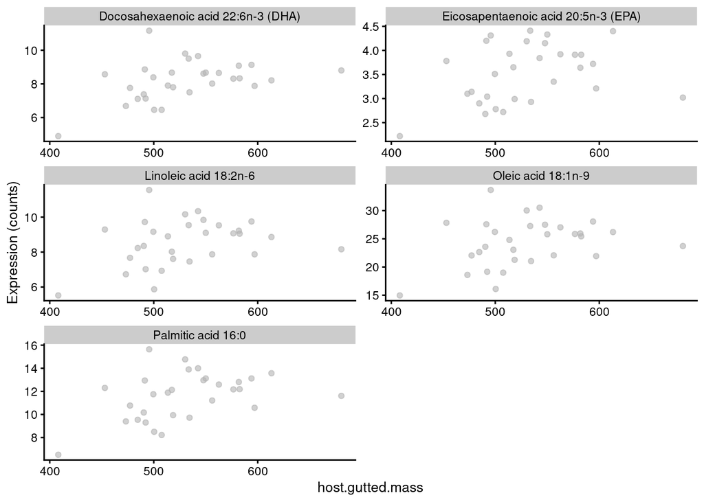

```r
p <- plotExpression(
    altExp(mae[[1]], "relevant"),
    features = rownames(altExp(mae[[1]], "relevant")),
    x = "host.gutted.mass",
    assay.type = "counts",
    scales = "free"
    )
p
```

As a result of this initial analysis of fatty acids, we discovered that the size of the salmon appears to have some association with fatty acid concentrations, although this association is not statistically significant.

## Microbiota, mass and treatment

### Microbial composition

As a first step in analysing microbiota data, we summarize the microbial composition with relative abundance barplot.

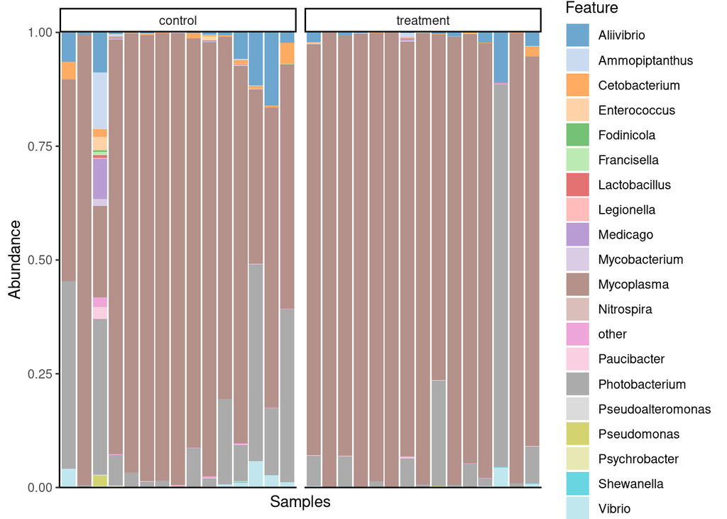

```r
p <- plotAbundance(
    altExp(mae[[2]], "core_genus"),
    assay.type = "relabundance",
    col.var = "treatment_group",
    facet.cols = TRUE, scales = "free_x"
    )
p
```

Salmon gut seems to be dominated by either genus *Mycoplasma* or *Photobacterium*.

### Is alpha diversity associated with treatment or mass of salmon?

Next, let’s calculate the Shannon alpha diversity index and test whether diversity is associated with both size and treatment.

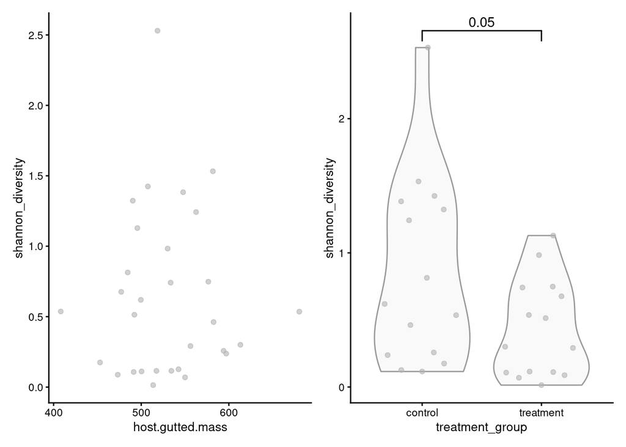

```r
# Calculate alpha diversity
mae[[2]] <- addAlpha(mae[[2]])
# Plot with metadata
p1 <- plotColData(mae[[2]], x = "host.gutted.mass", y = "shannon_diversity")
p2 <- plotColData(mae[[2]], x = "treatment_group", y = "shannon_diversity") +
    geom_signif(comparisons = list(c("control", "treatment")), )

p1 + p2
```

Once again, we observe a potential effect, this time between treatment and microbial diversity, although it is not statistically significant. Additionally, there is no association between diversity and mass.

Let’s analyze whether we can find similar effect with beta diversity. Here we perform Principal Coordinate Analysis (PCoA) with Bray-Curtis dissimilarity.

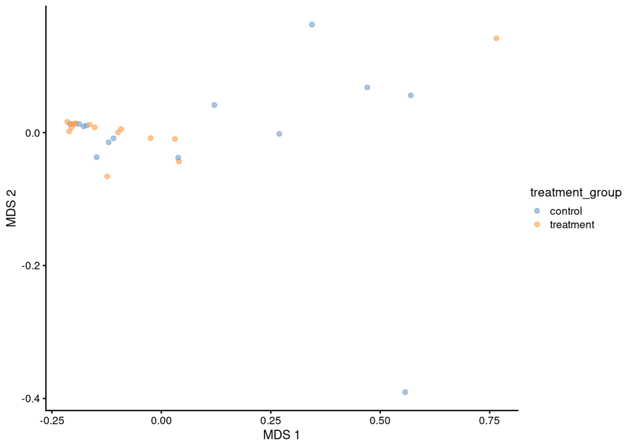

```r
# Run PCoA
mae[[2]] <- runMDS(
    mae[[2]],
    FUN = getDissimilarity,
    method = "bray",
    assay.type = "relabundance"
)

# Display dissimilarity on a plot
p <- plotReducedDim(mae[[2]], "MDS", colour_by = "treatment_group")
p
```

It seems that there are handful of samples that differ from others. However, this effect seems not to be associated with the treatment group.

## Multi-omic integration

Multi-omic factor analysis (MOFA) allows us to discover latent factors that underlie the biological differences by taking in consideration 2 or more omic assays. To cite the original authors, “MOFA can be viewed as a statistically rigorous generalization of (sparse) principal component analysis (PCA) to multi-omics data”.

By applying MOFA analysis, our goal is to determine whether metagenomics and fatty acids exhibit shared variability, ultimately assessing whether the microbial community is associated with fatty acid composition.

```r
mae_temp <- mae
mae_temp[[2]] <- altExp(mae_temp[[2]], "prev_genus")

# Extract only transformed metagenomic assays for MOFA analysis
assays(mae_temp[[1]]) <- assays(mae_temp[[1]])[
    names(assays(mae_temp[[1]])) %in% c("log10")
]
assays(mae_temp[[2]]) <- assays(mae_temp[[2]])[
    names(assays(mae_temp[[2]])) %in% c("counts")
]

# Transform MAE object to MOFA model
model <- create_mofa_from_MultiAssayExperiment(mae_temp)

# Set model's options
model_opts <- get_default_model_options(model)
model_opts$num_factors <- 5
model_opts$likelihoods[[2]] <- "poisson"
train_opts <- get_default_training_options(model)
train_opts$maxiter <- 20000

# Change convergence mode to slightly improve accuracy
train_opts$convergence_mode <- "slow"

# Prepare MOFA model
model <- prepare_mofa(
    object = model,
    model_options = model_opts,
    training_options = train_opts
)

# Train model
model <- run_mofa(model, use_basilisk = TRUE)
```

For sanity check, we expect factors to be uncorrelated.

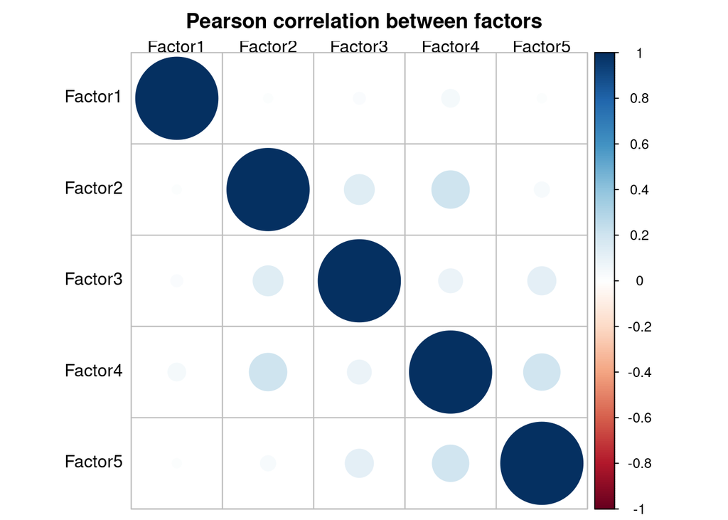

```r
plot_factor_cor(
    model,
    method = "pearson",
    cl.ratio = 0.2,
    tl.srt = 0,
    title = "Pearson correlation between factors",
    mar = c(0, 0, 2, 0),
)
```

Overall, we do not observe highly correlated factors which is the a good sign.

Next, we will plot the variances explained by each factor.

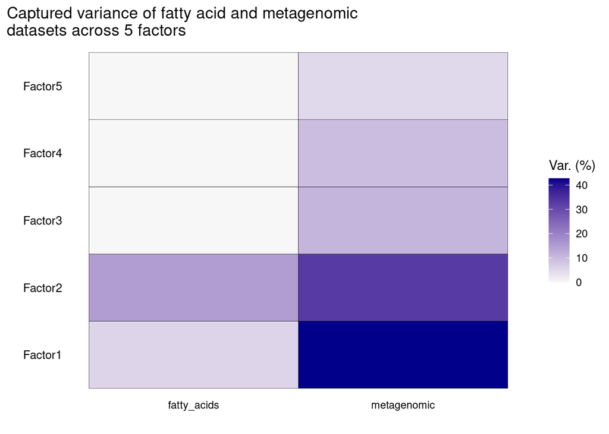

```r
p <- plot_variance_explained(model) +
    labs(title = "Captured variance of fatty acid and metagenomic\ndatasets across 5 factors") +
    theme(plot.title.position = "plot")
p
```

Factor 1 captures the majority of the variance in the metagenomics data, although some variability remains to be captured by other factors. Factor 2 captures the shared variability between the metagenomics and fatty acid data.

Before exploring the shared variability, we first examine which taxa’s variability is captured by Factor 1.

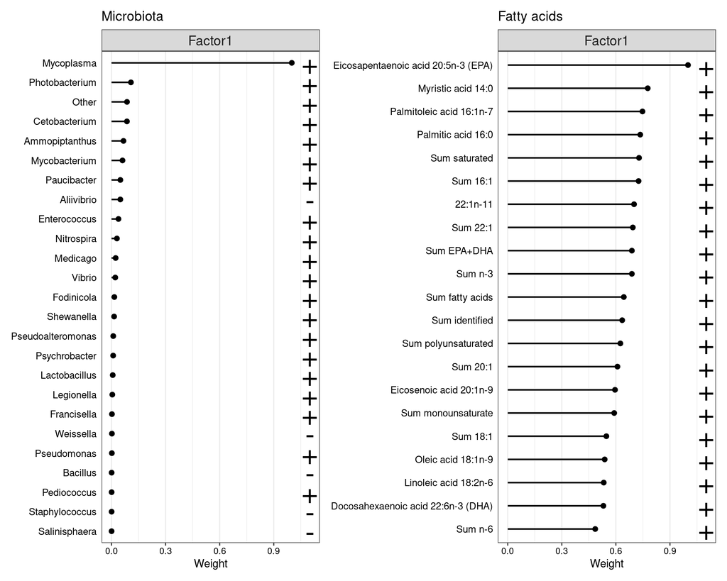

```r
p1 <- plot_top_weights(model, view = "metagenomic", factors = 1, nfeatures = 25) +
  labs(title = "Microbiota")
p2 <- plot_top_weights(model, view = "fatty_acids", factors = 1, nfeatures = 25) +
  labs(title = "Fatty acids")

p1 + p2
```

From the plot above, we can see that the first factor captures mostly the variability in *Mycoplasma*.

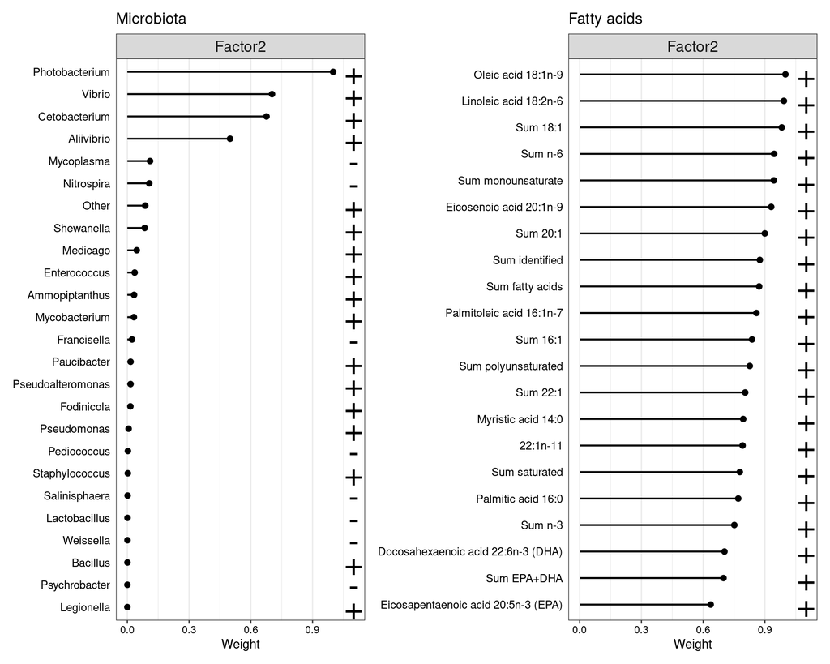

```r
p1 <- plot_top_weights(model, view = "metagenomic", factors = 2, nfeatures = 25) +
  labs(title = "Microbiota")
p2 <- plot_top_weights(model, view = "fatty_acids", factors = 2, nfeatures = 25) +
  labs(title = "Fatty acids")

p1 + p2
```

## Conclusions

The present case study has demonstrated how easy and fast it is to download large dataset and transform the data into a `MultiAssayExperiment`, which in turn gives the researchers access to an extensive plethora of downstream tools, such `mia` and `MOFA2` that can be used to pre-process and visualize the multi-omics data.

```
#> R Under development (unstable) (2024-01-12 r85803)
#> Platform: x86_64-pc-linux-gnu
#> Running under: Linux Mint 21
#>
#> Matrix products: default
#> BLAS:   /opt/R/devel/lib/R/lib/libRblas.so
#> LAPACK: /usr/lib/x86_64-linux-gnu/lapack/liblapack.so.3.10.0
#>
#> locale:
#>  [1] LC_CTYPE=en_US.UTF-8       LC_NUMERIC=C
#>  [3] LC_TIME=en_US.UTF-8        LC_COLLATE=en_US.UTF-8
#>  [5] LC_MONETARY=fi_FI.UTF-8    LC_MESSAGES=en_US.UTF-8
#>  [7] LC_PAPER=fi_FI.UTF-8       LC_NAME=C
#>  [9] LC_ADDRESS=C               LC_TELEPHONE=C
#> [11] LC_MEASUREMENT=fi_FI.UTF-8 LC_IDENTIFICATION=C
```

[output cut: 113 more lines]

## References

Quinn, Thomas P., Ionas Erb, Greg Gloor, Cedric Notredame, Mark F. Richardson, and Tamsyn M. Crowley. 2019. “A Field Guide for the Compositional Analysis of Any-Omics Data.” *GigaScience* 8 (9): giz107. https://doi.org/10.1093/gigascience/giz107.

Zarkasi, K. Z., G. C. J. Abell, R. S. Taylor, C. Neuman, E. Hatje, M. L. Tamplin, M. Katouli, and J. P. Bowman. 2014. “Pyrosequencing-Based Characterization of Gastrointestinal Bacteria of Atlantic Salmon (Salmo Salar L.) Within a Commercial Mariculture System.” *Journal of Applied Microbiology* 117 (1): 18–27. https://doi.org/10.1111/jam.12514.